# Wetland Inundate Code

# Code Description

Below is code for a simple inundation model. Sometimes called a bathtub model, this analysis estimates the extent and volume of inundation based on (1) specified elevation, (2) digital elevation model, and (3) location of depressional wetland. The analysis is loosely based on [Jones et al., [2018]](https://doi.org/10.1002/hyp.11405) and the [Topographic Depression Identification Model (TDI)](https://doi.org/10.1002/2013GL059114).

# Step 1: Create Synthetic DEM

Normally, you would just read in a DEM for the analysis. However, for the purposes of this tutorial, we will make our own DEM with depresional wetlands. [So, just run this code. Don’t worry too much about the contents for now!]

## 1.1 Setup your workspace

As always, setup your workspace and download appropriate packages.

```r
#Clear Memory
rm(list=ls(all=TRUE))

#Download packages
library(raster)
library(sp)
library(rgdal)
library(rgeos)
library(actuar)
library(poweRlaw)
library(dplyr)
```

## 1.2 Define Variables

Define variables that describe the synthetic landscape

```r
#lanscape size (Note, it will be a square)
area<-1000 #ha

#Size of cell_size cell (e.g. length of one side)
cell_size<-3 #m

#wetland depth
invert<-1 #m

#landscape slope
slope<-0.001 #m/m
```

## 1.3 Create blank raster

Create raster that using variables listed above

```r
#Convert units to meters
area<-area*10000 #convert to m^2

#Define coordinates
x<-matrix(0, nrow=sqrt(area)/cell_size, ncol=sqrt(area)/cell_size)
y<-matrix(0, nrow=sqrt(area)/cell_size, ncol=sqrt(area)/cell_size)
z<-matrix(0, nrow=sqrt(area)/cell_size, ncol=sqrt(area)/cell_size)

#Add coordinates
for(i in 1:(sqrt(area)/cell_size)){
  x[,i]<-i*cell_size-(cell_size/2)
  y[i,]<-i*cell_size-(cell_size/2)
  }

#Add elevation data (valley slope)
interp<-approxfun(data.frame(c(1,sqrt(area)/cell_size), c(100, 100-slope*sqrt(area))))
for(i in 1:(sqrt(area)/cell_size)){z[i,]<-interp(i)}

#Add natural variation
z_var<-matrix(rnorm(length(z), mean=1, sd=0.001), nrow=sqrt(area)/cell_size, ncol=sqrt(area)/cell_size)
z<-z*z_var

#Create Raster
dem <-raster(z,
              xmn=range(x)[1], xmx=range(x)[2],
              ymn=range(y)[1], ymx=range(y)[2]
)

#clean up workspace
remove(list=c("x","y","z","i","slope"))
```

## 1.4 Add wetlands to raster

```r
#Determine number, size, and location of wetlands~~~~~~~~~~~~~~~~~~~~~~~~~~~~~~~~~~~
#determine number and size of wet
wetland_area<-area*0.10 #From Van Meter and Basu 2015 (Des Moines Lobe)

#Iterate through wetland scenarios until correct area
set.seed(1)
n.wetlands<-10
pnts<-rep(wetland_area/n.wetlands, n.wetlands)

#Randomly select location of each wetland
pnts<-data.frame(coordinates(sampleRandom(dem,n.wetlands, sp=T)), pnts)
  colnames(pnts)<-c("x","y", "area_m2")

#add wetid data
pnts<-pnts[order(-pnts$area_m2),]
pnts$WetID<-seq(1,length(pnts[,1]))

#calculate wetland volume and depth
p<-4 #shape factor from Hayashi and Kamp [200]
pnts$volume_m3<-(0.25*(pnts$area_m2/10000)^1.4742)*10000 #Equation  from Wu and Lane [2016]
pnts$max_depth_m<-(pnts$volume_m3*(1+2/p))/pnts$area_m2

#add z data and create shp
pnts$z<-raster::extract(dem, pnts[,c("x","y")])

#add data about the watershed depth
pnts$ws_depth<-abs(rnorm(nrow(pnts),2,0.5))

#Create Function to add wetland shape (with bathymetry)~~~~~~~~~~~~~~~~~~~~~~~~~~~~~
fun<-function(WetID){
  #Setup~~~~~~~~~~~~~~~~~~~~~~~~~~~~~~~~~~~~~~~~~~~~~~~~~~~
  #define variables
  area_max<-pnts$area_m2[pnts$WetID==WetID]
  x<-pnts$x[pnts$WetID==WetID]
  y<-pnts$y[pnts$WetID==WetID]
  z<-pnts$z[pnts$WetID==WetID]
  ws_depth<-pnts$ws_depth[pnts$WetID==WetID]
  depth<-pnts$max_depth_m[pnts$WetID==WetID]

  #create circle function to define circle
  circle.fun<-function(area, x, y){
    radius<-(area/pi)^.5
    circle<-seq(0, 2 * pi, length.out = 2*pi*sqrt(area/pi))
    circle<-cbind(x + radius * sin(circle), y + radius * cos(circle))
    circle
  }

  #Represent bathymetry with points~~~~~~~~~~~~~~~~~~~~~~~~
  #Calculate variables
  radius<-(area_max/pi)^0.5
  n<-round(radius/cell_size)

  #create dataframe to house points
  bath<-data.frame(matrix(0, ncol=3))
    colnames(bath)<-c("x","y","z")
  bath$x[1]<-x
  bath$y[1]<-y
  bath$z[1]<-z-depth

  #Add "rings" to bath df
  for(i in 1:(n+1)){
    area_ring<-pi*(i*cell_size)^2
    df<-data.frame(circle.fun(area_ring, x,y),depth*(i*cell_size/radius)^p+(z-depth))
      colnames(df)<-c("x","y","z")
    bath<-rbind(bath,df)
  }

  #Adjust elevation for watershed invert elevation
  bath$z<-bath$z-ws_depth

  #Represent watershed surface~~~~~~~~~~~~~~~~~~~~~~~~~~~~~
  #Calculate variables
  ws_radius<-(area_max*10/pi)^0.5
  m<-round((ws_radius-radius)/cell_size)

  #create dataframe to house points
  ws<-data.frame(matrix(0, ncol=3))
  colnames(ws)<-c("x","y","z")

  #Add "rings" to ws df
  for(i in 0:m){
    area_ring<-pi*(i*cell_size+radius)^2
    df<-data.frame(circle.fun(area_ring, x,y),ws_depth/(ws_radius-radius)*(i*cell_size)+(z-ws_depth))
    colnames(df)<-c("x","y","z")
    ws<-rbind(ws,df)
  }
  ws<-ws[-1,]

  #Create raster of Wetland Bathymetry~~~~~~~~~~~~~~~~~~~~~~~~~~~~~~~~~~~~~~~~~~
  #Conbime bathymetry and ws surface
  bath<-rbind(bath,ws)

  #Remove points that are > current dem surface
  bath$dem<-raster::extract(dem,bath[,1:2])
  bath<-bath[bath$z<bath$dem,]

  #If any points are left:
  if(nrow(bath)>1){

    #Create gird
    wetland.grd<-rasterize(bath[,1:2], dem, bath[,3])

    #Create Clip
    clip<-wetland.grd*0
    clip[is.na(clip)] <- 1
    wetland.grd[is.na(wetland.grd)] <- 0

    #append dem
    dem<-dem*clip+wetland.grd

    #assign dem to the global environment
    assign('dem', dem, envir = .GlobalEnv)
  }
}

#Run function
for(i in 1:length(pnts[,1])){fun(i)}

#Smooth with raster filter
dem<-focal(dem, w=matrix(1/25,nrow=5,ncol=5))
```

## 1.5 Plot synthetic landscape!

Below is a plot of the synthetic landscape we will use for delineation today!

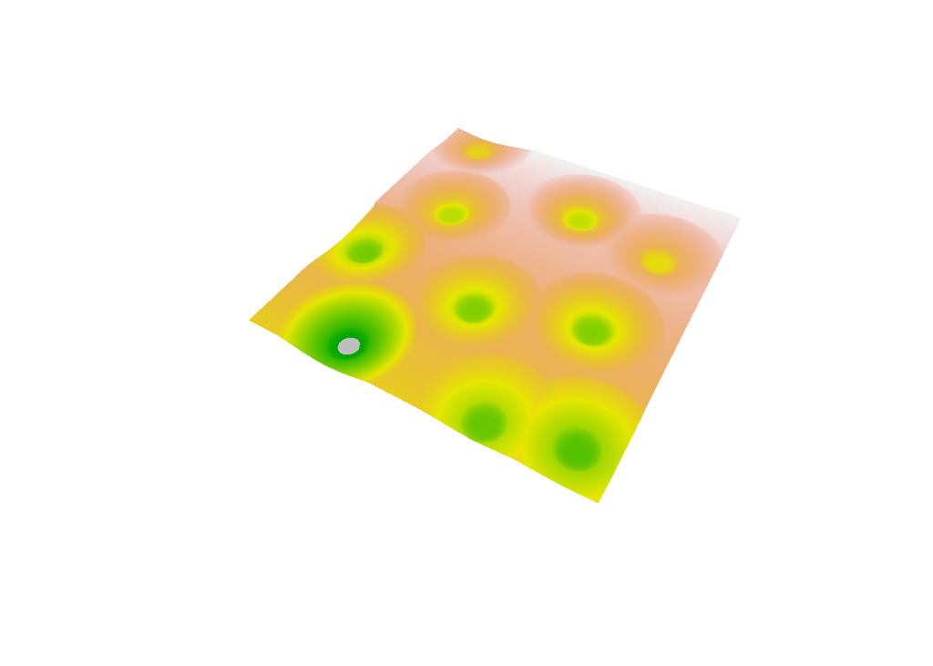

# Step 2: Delineate Wetland Basins

Now that we have created our synthetic landscape, we can seperate it into discrete endorheic (i.e., internally draining) basins. This step requires the use of the RPyGeo package. It’s worth noting, this package has to be run on a windows machine, requires both ArcGIS and Python, and require read/write access to the hard drive. For more information, read the documentation [here](https://cran.r-project.org/web/packages/RPyGeo/RPyGeo.pdf).

## 2.1 Setup RPyGeo workspace

Here, you will need to supply both path to python path and a seperate workspace. Note, the example below was configured for use on the SESYNC WinAnalytics Virtual machine. These paths will vary depending on your machine and specific access priveledges.

```r
#Read RPyGeo Library
require(RPyGeo)

#Create python environment
py.env<-rpygeo.build.env(python.path = "C:\\Python27\\ArcGIS10.2\\",
                         workspace = "C:\\ScratchWorkspace\\",
                         overwriteoutput = 1)

#Set working directory to scratchworkspace
setwd("C:\\ScratchWorkspace\\")
```

## 2.2 Identify internally draining basins

Here, you will pass files between the R and ArcGIS environments. When using Raster package functions (e.g., focal), the raster will need to be in the R environment. However, if you need to use ArcGIS geoprocessing tools, the raster has to be exported to the predefined workspace before completing the ArcGIS task. Once the new ArcGIS tasks has been completed, the updated file will then need to be read BACK into the R environment.

Cleare as mud right? See steps below:

```r
  #Convert DEM to planar coordinates
  dem@crs<-CRS("+proj=utm +zone=17 +ellps=WGS84 +datum=WGS84 +units=m +no_defs")
    #Note, in this case of this tutorial, we just simply assigned a planar coordinate system.
    #In real life, you will want to reproject using projectRaster()

  #Filter the DEM
  dem_filter.grd<- focal(dem, w=focalWeight(dem, 5, "Gauss"))
  dem_filter.grd<- focal(dem_filter.grd, w=focalWeight(dem, 5, "Gauss"))
  dem_filter.grd<- focal(dem_filter.grd, w=focalWeight(dem, 5, "Gauss"))
  dem_filter.grd@crs<-dem@crs
  writeRaster(dem_filter.grd,
              file="C:\\ScratchWorkspace\\dem_filter.asc",
              overwrite=T)

  #Fill sinks (up to 0.1m)
  rpygeo.geoprocessor(fun="Fill_sa",
                      c("dem_filter.asc",
                        "dem_fill",
                         0.3048/2),
                      env=py.env)
```

```r
  #Compute Flow Direction
  rpygeo.FlowDirection.sa("dem_fill","fdr_esri", env=py.env)
```

```r
  #Identify Sink
  rpygeo.Sink.sa("fdr_esri", "sink", env=py.env)
```

```r
  #Run basin tool
  rpygeo.geoprocessor(fun="Basin_sa",
                      c("fdr_esri","basin"),
                      env=py.env)
```

```r
  #Convert sink and basin to polygons
  rpygeo.geoprocessor(fun="RasterToPoint_conversion",
                      c("sink", "sink.shp", "VALUE"),
                      env=py.env)
```

```r
  rpygeo.geoprocessor(fun="RasterToPolygon_conversion",
                      c("basin", "basin.shp", "NO_SIMPLIFY","VALUE"),
                      env=py.env)
```

```r
  #Bring basin shapes back into the R environment
  basin.shp<-readOGR("C:\\ScratchWorkspace\\.","basin")
  #For the sake of this exercise, lets remove non-wetland basins
  basin.shp<-basin.shp[rank(gArea(basin.shp, byid=T))>(length(basin.shp)-10), ]
```

## 2.3 Estimate storage capacity using the TDI

First, we will create a function to estimate storage capacity for each basin based on wetland stage.

```r
inundate.fun<-function(n){
  #Select basin
  temp.shp<-basin.shp[n,]

  #Convert to raster
  res<-res(dem)[1]
  ext<-raster(extent(temp.shp), res=res)
  temp.grd<-rasterize(temp.shp, ext, field=1)
  temp.grd<-temp.grd*dem

  #Create Minimum Raster
  temp_min.grd<-temp.grd*0+minValue(temp.grd)

  #Create function to return conditional raster
  Con<-function(condition, trueValue, falseValue){
    return(condition * trueValue + (!condition)*falseValue)
  }

  #Create function to calculate inundation area/volume
  inundate<-function(z){
    area<-Con(temp.grd>(temp_min.grd+z),0,1)
    volume<-(((z+temp.grd)-temp_min.grd)*area)*res(area)[1]*res(area)[2]
    outflow<-cellStats(area*boundaries(temp_min.grd, type="inner"), 'sum')
    c(cellStats(area, 'sum')*res(area)[1]*res(area)[2], #area (m^2)
      cellStats(volume, 'sum'), #volume (m^3)
      outflow #Outflow length (3 m increments)
    )
  }

  #Conduct inundation calculation and store results in df
  df<-c(n, #Unique identifer
        minValue(temp.grd), #Minimum Elevation
        xyFromCell(temp.grd,max(which.min(temp.grd)))[1], #X Value
        xyFromCell(temp.grd,max(which.min(temp.grd)))[2], #Y Value
        gArea(temp.shp), #area of shpape
        c(t(sapply(seq(0.1,3,0.1),inundate))) #Area, Volume, and Spill Area
  )
  #print dataframe
  df
}
```

Execute the function for the 10 wetlands!

```r
df<-lapply(seq(1,10),inundate.fun)
df<-data.frame(do.call(rbind, df))
colnames(df)<-c("basin.id",
                "min_elevation",
                "long",
                "lat",
                "basin_area",
                paste0("area_",seq(0.1,3,0.1)),
                paste0("volume_",seq(0.1,3,0.1)),
                paste0("spill_length",seq(0.1,3,0.1)))
```

Now, determine storage capacity based on spill boundary threshold. [Note, here we aren’t goign to worry about ditches - ie potential storage capacity – because we didn’t insert ditches in to the synthetic landscape model.]

```r
#Create function to estimate spill elevation
spill.fun<-function(n){
  #Gather overflow data
  df<-df[n,]
  df<-data.frame(seq(0.1,3, 0.1),
                 as.numeric(paste(df[6:35])),
                 as.numeric(paste(df[36:65])),
                 as.numeric(paste(df[66:95])))
  colnames(df)<-c("z","area", "volume", "spill")

  #Define change in spill length
  df$ds<-0
  df$ds[1]<-0
  df$ds[2:30]<-df$spill[2:30]-df$spill[1:29]

  #Print "spill" events
  #If no spill <2m
  if(sum(df$spill, na.rm=T)==0){
    c(n,df$z[30], df$area[30], df$volume[30],df$z[30], df$area[30], df$volume[30])
  }else{
    #If no change in spill >=3
    if(max(df$ds,na.rm=T)<3){
      #If max spill length less than 3m
      if(max(df$spill, na.mr=T)>=3){
        c(n, #Basin ID
        min(df$z[df$ds>=1]), #depth of ditch
        min(df$area[df$ds>=1]), #area of ditch
        min(df$volume[df$ds>=1]), #volume of ditch
        min(df$z[df$spill>3]), #depth of wetland
        min(df$area[df$spill>3]), #area of wetland
        min(df$volume[df$spill>3])) #volume of wetland
      }else{
        c(n, #Basin ID
        min(df$z[df$ds>=1]), #depth of ditch
        min(df$area[df$ds>=1]), #area of ditch
        min(df$volume[df$ds>=1]), #volume of ditch
        min(df$z[df$ds>=1]), #depth of wetland
        min(df$area[df$ds>=1]), #area of wetland
        min(df$volume[df$ds>=1])) #volume of wetland
        }
    }else{
      #If change in spill >3
      c(n, #Basin ID
      min(df$z[df$ds>=1]), #depth of ditch
      min(df$area[df$ds>=1]), #area of ditch
      min(df$volume[df$ds>=1]), #volume of ditch
      min(df$z[df$ds>=3]), #depth of wetland
      min(df$area[df$ds>=3]), #area of wetland
      min(df$volume[df$ds>=3])) #volume of wetland
      }
    }
}

#Execute the function
output<-lapply(seq(1,10),spill.fun)
output<-data.frame(do.call(rbind, output))
colnames(output)<-c("n",
                    "d_ditch",
                    "a_ditch",
                    "v_ditch",
                    "d_wetland",
                    "a_wetland",
                    "v_wetland")

#Merge with master dataframe
df<-merge(df, output, by.x='basin.id', by.y='n')
```

# Step 3: Plot!!!

Finally, the step you’ve been waiting for! Let’s plot this bad boy!

## 3.1 Create output raster

Well, not so fast. First we have to create an output raster

```r
#Create function to create inundatoin raster for each basin
inundate.fun<-function(n){
  #Select basin
  temp.shp<-basin.shp[n,]

  #Convert to raster
  res<-res(dem)[1]
  ext<-raster(extent(temp.shp), res=res)
  temp.grd<-rasterize(temp.shp, ext, field=1)
  temp.grd<-temp.grd*dem

  #Create Minimum Raster
  temp_min.grd<-temp.grd*0+minValue(temp.grd)

  #Create function to return conditional raster
  Con<-function(condition, trueValue, falseValue){
    return(condition * trueValue + (!condition)*falseValue)
  }

  #Create function to calculate inundation area/volume
  depth<-df$d_wetland[n]
  inundation<-Con(temp.grd>(temp_min.grd+depth),0,1)

  #Change inundation extent
  inundation<-crop(extend(inundation, dem), dem)
  inundation[is.na(inundation)]<-0

  #Export Inundation Raster
  inundation
}

#Now, use a loop and raster algebra to compline inundation for all 10 basins
wetland<-dem*0
for(i in 1:10){
  print(i)
  temp<-inundate.fun(i)
  wetland<-wetland+temp
}
```

```
## [1] 1
## [1] 2
## [1] 3
## [1] 4
## [1] 5
## [1] 6
## [1] 7
## [1] 8
## [1] 9
## [1] 10
```

```r
wetland[wetland==0]<-NA
```

## 3.2 Plotting

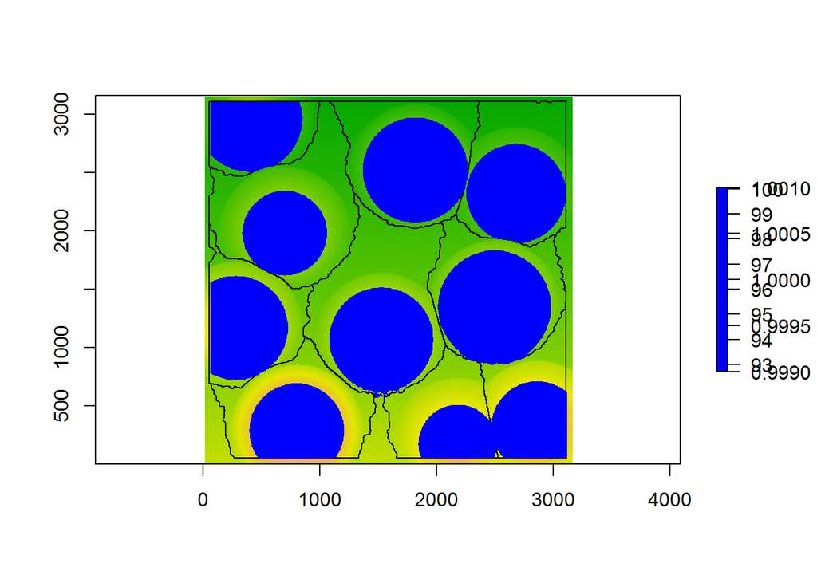

```r
plot(dem)
plot(basin.shp, add=T)
plot(wetland, col="blue", add=T)
```

For more infomration, contact Nate Jones (njones@sesync.org)